# Lab 7

Maxim Dokukin

Remember, **follow the instructions below and use R Markdown to create a pdf document with your code and answers to the following questions on Gradescope.** You may find a template file by clicking “Code” in the top right corner of this page.

## 1. In your own words, explain the difference between `dnorm()`, `pnorm()`, `qnorm()`, and `rnorm()`.

`dnorm()` - PDF `pnorm()` - CDF `qnorm()` - to get quantile `rnorm()` - get random sample ———- 2. Suppose we simulate `x <- runif(1)`. What is the distribution of `qnorm(x)`? ———- Normal?

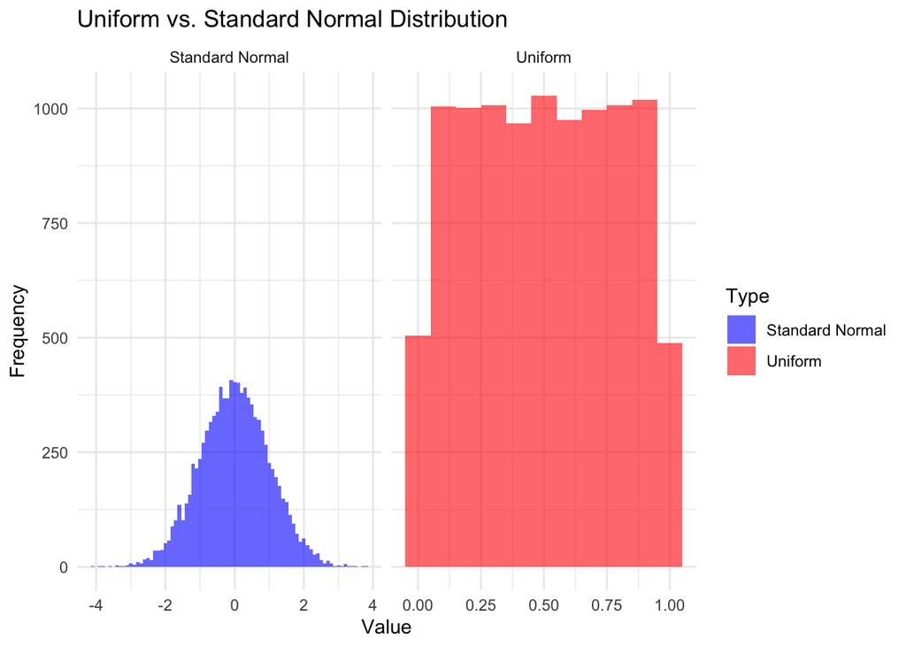

```r
library(ggplot2)

# Generate a large sample of uniformly distributed numbers
uniform_sample <- runif(10000)

# Apply qnorm to transform these numbers to a Standard Normal distribution
normal_sample <- qnorm(uniform_sample)

# Create a data frame for plotting
data <- data.frame(Value = c(uniform_sample, normal_sample),
                   Type = factor(rep(c("Uniform", "Standard Normal"), each = 10000)))

# Plot the distributions
ggplot(data, aes(x = Value, fill = Type)) +
  geom_histogram(alpha = 0.6, position = "identity", binwidth = 0.1) +
  scale_fill_manual(values = c("blue", "red")) +
  theme_minimal() +
  labs(title = "Uniform vs. Standard Normal Distribution",
       x = "Value",
       y = "Frequency") +
  facet_wrap(~Type, scales = "free_x")
```

## 3. Suppose we simulate `x <- rnorm(1)`. What is the distribution of `pnorm(x)`?

## B. Gambler’s ruin

A and B are playing a coin flipping game. A starts with $n_a$ pennies and B starts with $n_b$ pennies. A coin is flipped repeatedly and if it comes up heads, B gives A a penny. If it comes up tails, A gives B a penny. The game ends when one player has no more pennies.

4. Write a function `run_one_sim(seed, n_a, n_b)` to simulate one game. Repeatedly use your code with different values of `seed` to estimate each player’s probability of winning when $n_a = n_b = 10$.
5. Use your function to estimate each player’s probability of winning when $n_a = 1,\ldots, 5$ and $n_b = 1,\ldots, 5$, testing every combination. Organize your results in a 5 by 5 matrix and print it out. What do you notice?

## C. One-dimensional random walks

In this part, you will simulate a one-dimensional random walk. Suppose you are at the point $x$ at time $t$. At time $t+1$, the probability of moving forwards to $x+1$ is $p$ and the chance of moving backwards to $x-1$ is $1-p$. Assume that at time $t=1$, you are at $x_1=0$.

6. Write a function `random_walk()` that takes as input a numeric `n_steps` and a numeric $p$ and simulates `n_steps` steps of the one-dimensional random walk with forward probability $p$. You may have other input arguments if desired. The output should be a length vector of length `n_steps` starting with 0 where the $i$th entry represents the location of the random walker at time $t=i$. For example, `random_walk(5, .5)` may return the vector $(0, 1, 2, 1, 2)$.
7. Use your function to generate a random walk of 500 steps with probability $.55$ and generate a line graph with $t=1,\ldots, 500$ on the x-axis and $x_1,\ldots, x_{500}$ on the y-axis.
8. Use your function to generate two more random walks of 500 steps with probability $p$, where $p\sim \mathrm{Unif}(0, 1)$ and create a line graph with all three of your random walks, using different colors for each walk.